# Tutorial, Week 3: Text mining 1

SECU0050

B Kleinberg, J Kamps

30 Jan 2020

Aims of this tutorial:

- understanding text data through numerical representations
- examining a corpus of UK rap music
- calculating and comparing readability scores

*Note: this tutorial assumes that you have the packages `quanteda` and `stringr` installed.*

## Task 1: Understanding text data through numerical representations

Before we can work with text data in a more advanced manner, it is good to understand how text data is represented numerically. R - and quanteda specifically - contain numerous “built-in” datasets that you can use to understand concepts that you have learned in the lectures.

To get an overview of the packages that quanteda provides, have a look at the [online docs](https://quanteda.io/reference/index.html#section-data).

With the command below, you can look at the dataset of all inaugural speeches of US presidents (uncomment and run):

```r
library(quanteda)
library(stringr)
summary(data_corpus_inaugural)
```

```
Corpus consisting of 58 documents:

            Text Types Tokens Sentences Year  President       FirstName
 1789-Washington   625   1538        23 1789 Washington          George
 1793-Washington    96    147         4 1793 Washington          George
      1797-Adams   826   2578        37 1797      Adams            John
  1801-Jefferson   717   1927        41 1801  Jefferson          Thomas
  1805-Jefferson   804   2381        45 1805  Jefferson          Thomas
    1809-Madison   535   1263        21 1809    Madison           James
    1813-Madison   541   1302        33 1813    Madison           James
     1817-Monroe  1040   3680       121 1817     Monroe           James
     1821-Monroe  1259   4886       129 1821     Monroe           James
      1825-Adams  1003   3152        74 1825      Adams     John Quincy
    1829-Jackson   517   1210        25 1829    Jackson          Andrew
    1833-Jackson   499   1269        29 1833    Jackson          Andrew
   1837-VanBuren  1315   4165        95 1837  Van Buren          Martin
   1841-Harrison  1896   9144       210 1841   Harrison   William Henry
       1845-Polk  1334   5193       153 1845       Polk      James Knox
     1849-Taylor   496   1179        22 1849     Taylor         Zachary
     1853-Pierce  1165   3641       104 1853     Pierce        Franklin
   1857-Buchanan   945   3086        89 1857   Buchanan           James
    1861-Lincoln  1075   4006       135 1861    Lincoln         Abraham
    1865-Lincoln   360    776        26 1865    Lincoln         Abraham
      1869-Grant   485   1235        40 1869      Grant      Ulysses S.
      1873-Grant   552   1475        43 1873      Grant      Ulysses S.
      1877-Hayes   831   2716        59 1877      Hayes   Rutherford B.
   1881-Garfield  1021   3212       111 1881   Garfield        James A.
  1885-Cleveland   676   1820        44 1885  Cleveland          Grover
   1889-Harrison  1352   4722       157 1889   Harrison        Benjamin
  1893-Cleveland   821   2125        58 1893  Cleveland          Grover
   1897-McKinley  1232   4361       130 1897   McKinley         William
   1901-McKinley   854   2437       100 1901   McKinley         William
  1905-Roosevelt   404   1079        33 1905  Roosevelt        Theodore
       1909-Taft  1437   5822       159 1909       Taft  William Howard
     1913-Wilson   658   1882        68 1913     Wilson         Woodrow
     1917-Wilson   549   1656        59 1917     Wilson         Woodrow
    1921-Harding  1169   3721       148 1921    Harding       Warren G.
   1925-Coolidge  1220   4440       196 1925   Coolidge          Calvin
     1929-Hoover  1090   3865       158 1929     Hoover         Herbert
  1933-Roosevelt   743   2062        85 1933  Roosevelt     Franklin D.
```

[output cut: 10 more lines]

```
     1977-Carter   527   1376        52 1977     Carter           Jimmy
     1981-Reagan   902   2790       128 1981     Reagan          Ronald
     1985-Reagan   925   2921       123 1985     Reagan          Ronald
       1989-Bush   795   2681       141 1989       Bush          George
    1993-Clinton   642   1833        81 1993    Clinton            Bill
    1997-Clinton   773   2449       111 1997    Clinton            Bill
       2001-Bush   621   1808        97 2001       Bush       George W.
       2005-Bush   773   2319       100 2005       Bush       George W.
      2009-Obama   938   2711       110 2009      Obama          Barack
      2013-Obama   814   2317        88 2013      Obama          Barack
      2017-Trump   582   1660        88 2017      Trump       Donald J.

Source: Gerhard Peters and John T. Woolley. The American Presidency Project.
Created: Tue Jun 13 14:51:47 2017
Notes: http://www.presidency.ucsb.edu/inaugurals.php
```

*Note: don’t forget to load quanteda with the `library(...)` command.*

To access the actual texts, you can simply index the object: `data_corpus_inaugural[1]`. For now, rename the object to a variable called `US_speeches`:

```r
US_speeches[1]
```

```
                                                                                                                                                                                                                                                                                                            …
"Fellow-Citizens of the Senate and of the House of Representatives:\n\nAmong the vicissitudes incident to life no event could have filled me with greater anxieties than that of which the notification was transmitted by your order, and received on the 14th day of the present month. On the one hand, I…
```

Find answers to the following questions:

1. Which text has the highest number of characters per word? And whiich one the lowest?

```r
US_speeches$documents$char_per_word = nchar(US_speeches$documents$texts)/ntoken(US_speeches$documents$texts)
## use which.max to find the index (here: row) of the highest value
index_of_max = which.max(US_speeches$documents$char_per_word)
index_of_max
```

```
[1] 27
```

```r
## now return the row of that index
US_speeches$documents[index_of_max,]
```

|  | texts | Year | President | FirstName | char_per_word |
| --- | --- | --- | --- | --- | --- |
| 1893-Cleveland | My Fellow citizens, in obedience of the mandate of my countrymen I am about to dedicate myself to their service under the sanction of a solemn oath. Deeply moved by the expression of confidence and pe… | 1893 | Cleveland | Grover | 5.810824 |

```r
cpw <- function(text) {
  round(nchar(text) / ntoken(text, remove_punct = TRUE),2)
}
us_texts <- US_speeches$documents$texts
us_cpw = cpw(us_texts)
# Answers stored in these variables
max_cpw = which(us_cpw == max(us_cpw))
min_cpw = which(us_cpw == min(us_cpw))
max_cpw
```

```
text27
    27
```

```r
min_cpw
```

```
text51
    51
```

2. In which speech was the most punctuation used?

|  | texts | Year | President | FirstName | char_per_word | length_with_punct | length_without_punct | count_punct |
| --- | --- | --- | --- | --- | --- | --- | --- | --- |
| 1841-Harrison | Called from a retirement which I had supposed was to continue for the residue of my life to fill the chief executive office of this great and free nation, I appear before you, fellow-citizens, to take… | 1841 | Harrison | William Henry | 5.435149 | 9144 | 8446 | 698 |

3. Across all speeches, which token was used the most often?

```r
us_dfm <- dfm(US_speeches, remove_punct = TRUE)
most_used = topfeatures(us_dfm)[1]
most_used
```

```
  the
10082
```

Task 2: Re-examining Zipf’s law in US presidents’ speeches

From the required preparation, you will remember the essence of [Zipf’s Law](https://www.youtube.com/watch?v=fCn8zs912OE).

Answer these two questions:

1. Does the US speeches corpus support the finding of the 20 most common words in English language?

```r
top20_us
```

```
  the    of   and    to    in     a   our  that    we    be    is    it   for    by
10082  7103  5310  4526  2785  2246  2181  1789  1739  1481  1462  1389  1197  1083
 have which  with   not    as  will
 1011  1006   958   957   947   911
```

Does this finding surprise you? What could explain this?

2. For the first 10 most frequently occurring words in the corpus, does Zipf’s Law apply?

Here we will simplify Zipf’s Law to $freq_w \propto \frac{1}{rank_w}$, with $w$ being a given word. ($\propto$ stands for “proportional to”).

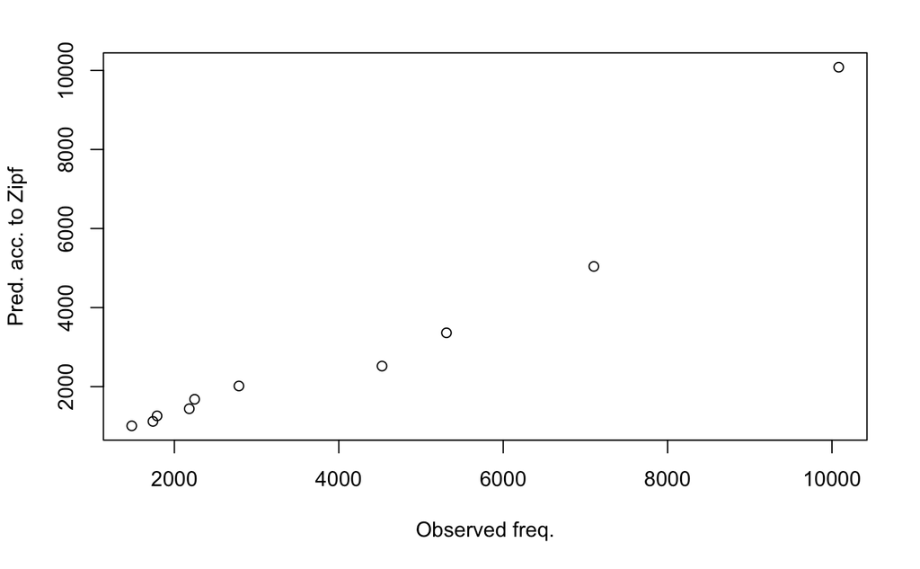

```r
top10_us = topfeatures(us_dfm, n = 10)
zipfs_prediction = round(top10_us[1] / 1:10)
plot(top10_us, zipfs_prediction, xlab = 'Observed freq.', ylab = 'Pred. acc. to Zipf')
```

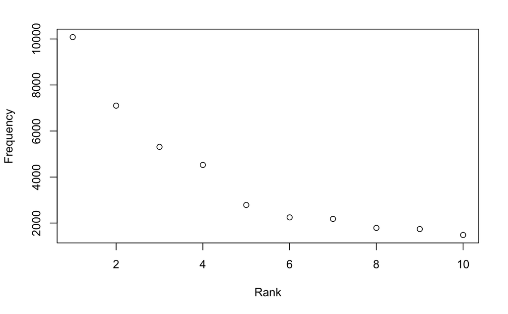

```r
plot(1:10, top10_us, xlab='Rank', ylab='Frequency')
```

## Task 3: Examining a corpus of UK rap music

For a research project related to a [study of UK drill music](https://arxiv.org/pdf/1911.01324.pdf), we have collated a dataset of UK rap music (non-drill).

You can access the dataset from: https://github.com/ben-aaron188/UCL_SECU0050/blob/master/data/uk_rap_corpus.RData. Download it to the folder where this tutorial file is located and the read the `.RData` file into your R workspace through the command below (uncomment and run):

```r
## Note: you need to set this path to the file location on your machine
load('/Users/bennettkleinberg/GitHub/UCL_SECU0050/data/uk_rap_corpus.RData')
```

You now have a corpus object in your workspace called `uk_rap_corpus`. *(The ID variable is structured as follows: `artistname_songname`)*.

Calculate the TFIDF for the whole corpus to answer the questions below:

1. Which token has the highest TFIDF value in the song “Borders” by “M.I.A.”?
2. Choose one token of your choice and plot its TFIDF value for all songs? Did you expect this finding?
3. Visualise the relationship between DF, IDF and log(IDF) as done in the lecture. Use the 100 words with the highest document frequency.

```r
# create a DFM
rap_dfm = dfm(uk_rap_corpus, remove_punct = TRUE)
# get the TFIDF
rap_tfidf = dfm_tfidf(rap_dfm, scheme_tf = 'count', scheme_df = 'inverse', k=1)
# inspect the first 10 rows and first 10 columns
rap_tfidf[1:10, 1:10]
```

```
Document-feature matrix of: 10 documents, 10 features (65% sparse).
10 x 10 sparse Matrix of class "dfm"
                       features
docs                           yo     part        2      a.i         and  j-kiss
  Jadakiss_A6           0.6601555 2.210658 2.600611 2.476397 0.080494963 7.42919
  M.I.A._ATENTion       0         0        0        0        0.008049496 0
  Jme_AWOH              0         0        0        0        0.040247482 0
  Madvillain_Accordion  0         0        0        0        0.088544459 0
  Scarlxrd_Achievements 0         0        0        0        0.016098993 0
  CASisDEAD_Adolescence 1.3203111 0        0        0        0.088544459 0
  Fredo_Again           0.6601555 0        0        0        0.088544459 0
  Jme_Again             0         0        0        0        0.040247482 0
  Scarlxrd_Ahead        0         0        0        0        0.008049496 0
  Sneakbo_Aigons        0         0        0        0        0.080494963 0
                       features
docs                    presenting         the       a6      from
  Jadakiss_A6             4.952794 0.023239860 12.38198 0.2284236
  M.I.A._ATENTion         0        0.007262456  0       0.4568471
  Jme_AWOH                0        0.013072421  0       0
  Madvillain_Accordion    0        0.029049825  0       0.2284236
  Scarlxrd_Achievements   0        0.026144843  0       0
  CASisDEAD_Adolescence   0        0.029049825  0       0.4568471
  Fredo_Again             0        0.040669755  0       0.6852707
  Jme_Again               0        0.034859790  0       0
  Scarlxrd_Ahead          0        0.005809965  0       0
  Sneakbo_Aigons          0        0.023239860  0       0.2284236
```

```r
borders_top_tokens
```

```
      system      western        solid        doors        wedom        stoop
   14.552075    13.052201    10.664561     9.980901     9.905587     9.905587
       north representing        scoop         east
    9.439841     9.201222     9.201222     8.858381
```

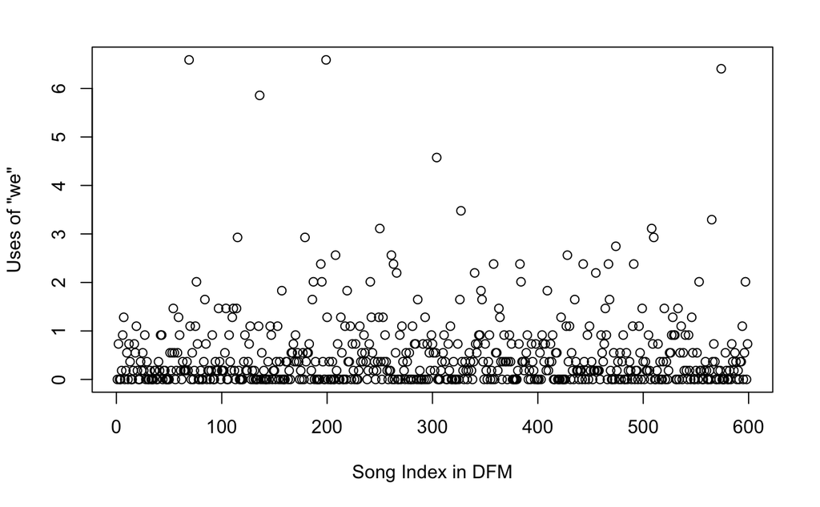

```r
# Question 2
# Let's choose the token "we" from Borders
we = convert(dfm_select(rap_tfidf, "we"), to='data.frame')
plot(we$we,xlab="Song Index in DFM", ylab="Uses of \"we\"")
```

```r
# Bonus: How to see which songs have a value higher than 3?
we3 = subset(we, we > 3)
we3
```

|  | document | we |
| --- | --- | --- |
| 69 | M.I.A._Borders | 6.589234 |
| 136 | Skitz_Dedication | 5.857097 |
| 199 | Akala_Freedom | 6.589234 |
| 250 | Chip_Human | 3.111583 |
| 304 | N.O.R.E._LaLa | 4.575857 |
| 327 | M.I.A._Macho | 3.477651 |
| 508 | Wiley_Standby | 3.111583 |
| 565 | Geko_Vibe | 3.294617 |
| 574 | Trim_Waco | 6.406200 |

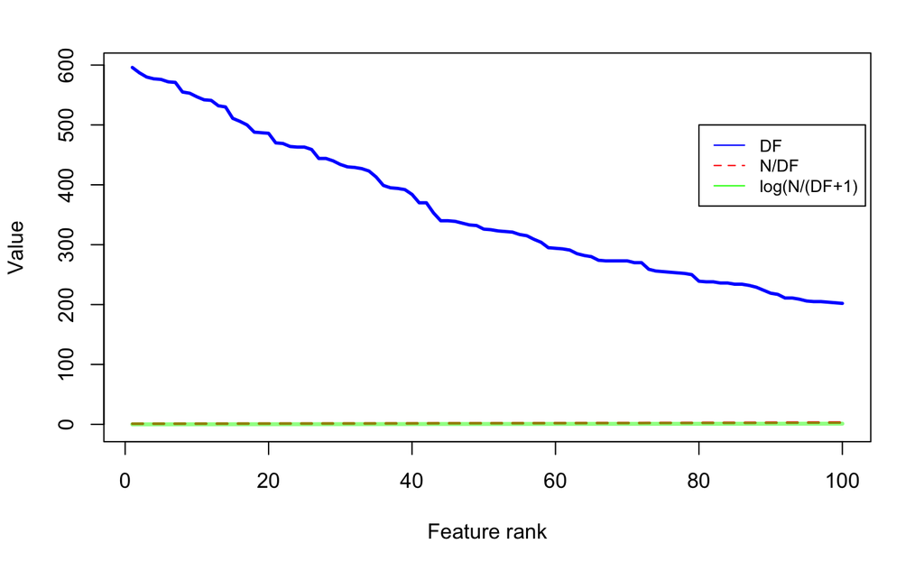

```r
# Question 3
top100 <- topfeatures(rap_dfm, n = 100, scheme = 'docfreq')
{
plot(top100, ylim=c(-5, max(top100)), type='l', col='blue', lwd=2.5, ylab="Value", xlab = 'Feature rank')
lines(max(top100)/top100, col='red', lty=2, lwd=2)
lines(log(max(top100)/(top100+1)), col=alpha('green',0.5), lty=1, lwd=3)
legend(80, 500, legend=c("DF", "N/DF", "log(N/(DF+1)"), col=c("blue", "red", 'green'), lty=c(1,2,1), cex=0.8)
}
```

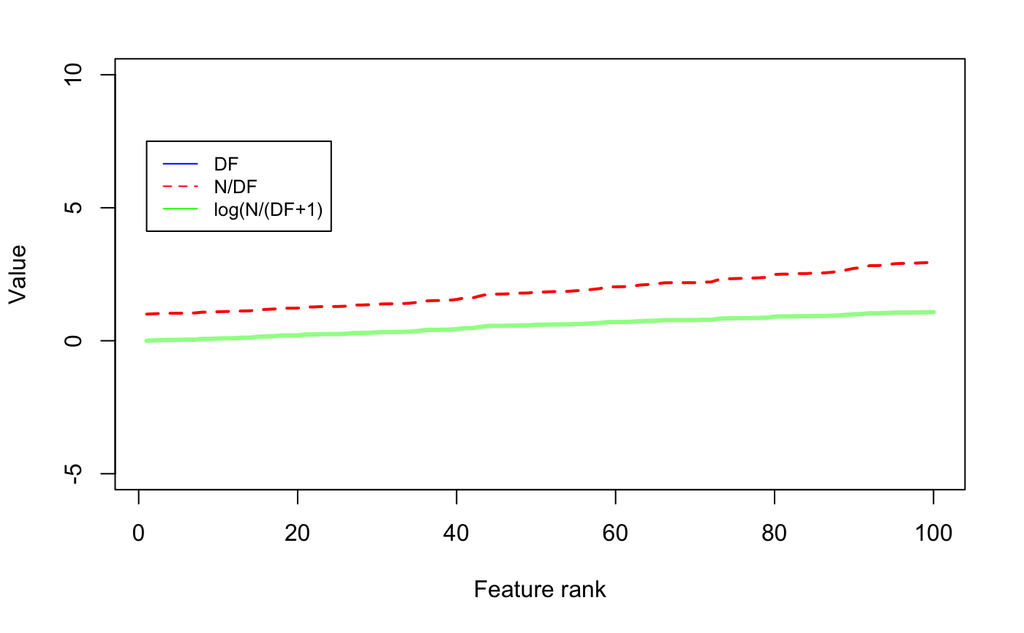

```r
# we can alo zoom in
{
plot(top100, ylim=c(-5, 10), type='l', col='blue', lwd=2.5, ylab="Value", xlab = 'Feature rank')
lines(max(top100)/top100, col='red', lty=2, lwd=2)
lines(log(max(top100)/(top100+1)), col=alpha('green',0.5), lty=1, lwd=3)
legend(1, 7.5, legend=c("DF", "N/DF", "log(N/(DF+1)"), col=c("blue", "red", 'green'), lty=c(1,2,1), cex=0.8)
}
```

## Task 4: Calculating and comparing readability scores

For the two corpora used in this tutorial - US speeches and UK rap lyrics - we are now interested in comparing the them on a range of text metrics.

Answer the questions below:

1. Which of the two corpora has the higher lexical diversity score?
2. For each corpus, which text has the lowest readability as measured through the “Automated Readability Index”? (Hint: have a look at the `readability` package and the wrapper function [here](https://github.com/ben-aaron188/r_helper_functions/blob/master/get_single_readability.R))
3. How did the readability of US presidents’ speeches change over time?

```r
# Helper function
corpus_lex_div = function(corpus_dfm) {
  mean(textstat_lexdiv(corpus_dfm)$TTR)
}
# Question 1:
# Compare lexical diversity of US speeches and UK Rap music.
# The values indicate that rap has more lexical diversity.
us_speech_ld = corpus_lex_div(us_dfm)
rap_ld = corpus_lex_div(rap_dfm)
```

```r
# Question 2:
# Compare readability of US speeches and UK Rap music
# Lowest readbility rap song: Wiley - Rubicon
# Lowest readability speech 1789 - Washington
us_readability = textstat_readability(US_speeches, measure="ARI")
rap_readability = textstat_readability(uk_rap_corpus, measure="ARI")
max_us = which.max(us_readability$ARI)
max_rap = which.max(rap_readability$ARI)
us_readability[max_us, 'document']
```

|  | document |
| --- | --- |
| 1 | 1789-Washington |

```r
rap_readability[max_rap, 'document']
```

|  | document |
| --- | --- |
| 437 | Wiley_Rubicon |

```r
# note that this gives you the row in which the max. value is and the directly only selects the 'document' column (which in this case contains the ID we need to determine which document it is)
```

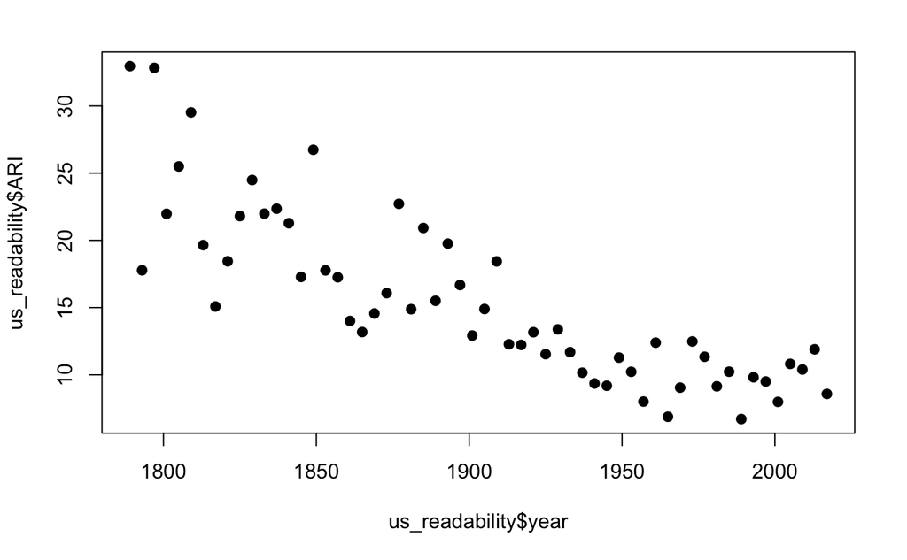

```r
# Question 3:
# add Year colum for US data
# Readability has improved over time
us_readability$year = US_speeches$documents$Year
plot(us_readability$year, us_readability$ARI, pch=19)
```

Finally: we now want to understand the relationship between readability, text meta indicators and lexical diversity.

For each corpus separately: Calculate the Coleman-Liau index, the lexical diversity and the number of characters per word. Now plot each of the three combinations of these measures in a scatterplot. Did the findings confirm your expectation?

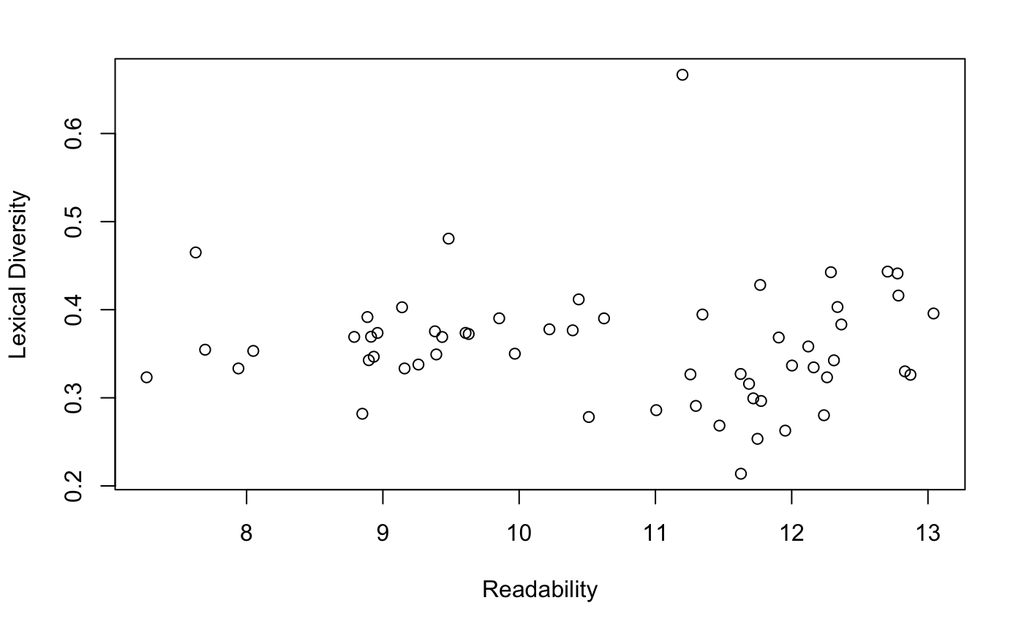

```r
# Coleman Liau Index
us_coleman = textstat_readability(US_speeches, measure="Coleman.Liau.short")$Coleman.Liau.short
rap_coleman = textstat_readability(uk_rap_corpus, measure="Coleman.Liau.short")$Coleman.Liau.short
# Lexical Diversity
us_ld_all = textstat_lexdiv(us_dfm)$TTR
rap_ld_all = textstat_lexdiv(rap_dfm)$TTR
# Characters per word
# us_cpw defined above
rap_cpw = cpw(uk_rap_corpus$documents$texts)
# US Plots
plot(us_coleman, us_ld_all, xlab = "Readability", ylab = "Lexical Diversity") # no correlation
```

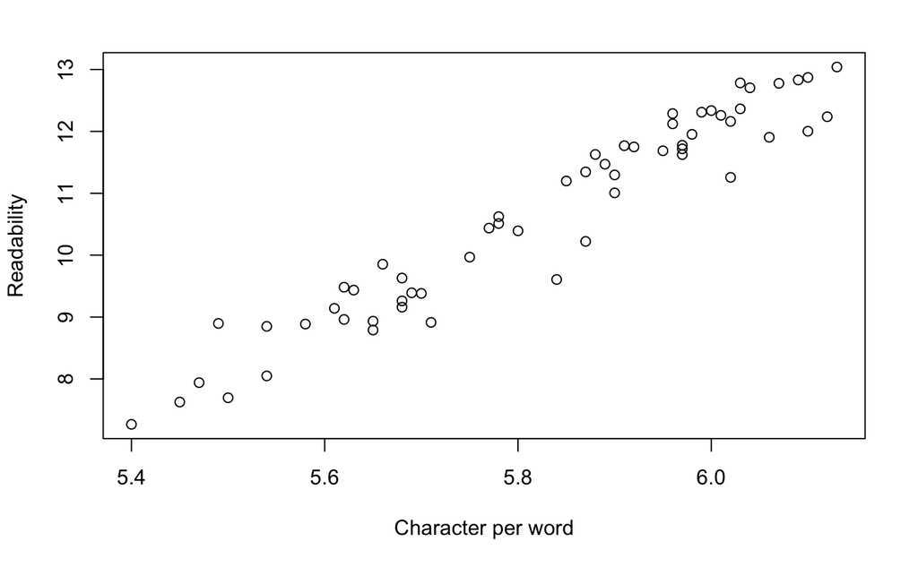

```r
plot(us_cpw, us_coleman, xlab = "Character per word", ylab = "Readability") # as characters perword increase, readability score increases (i.e. gets less readable)
```

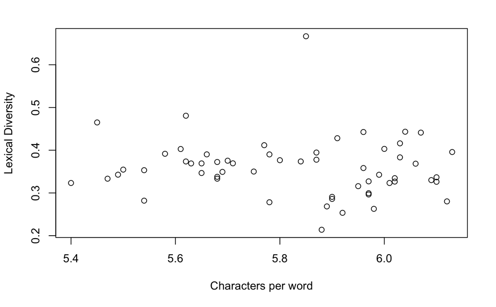

```r
plot(us_cpw, us_ld_all, xlab = "Characters per word", ylab = "Lexical Diversity") # no correlation
```

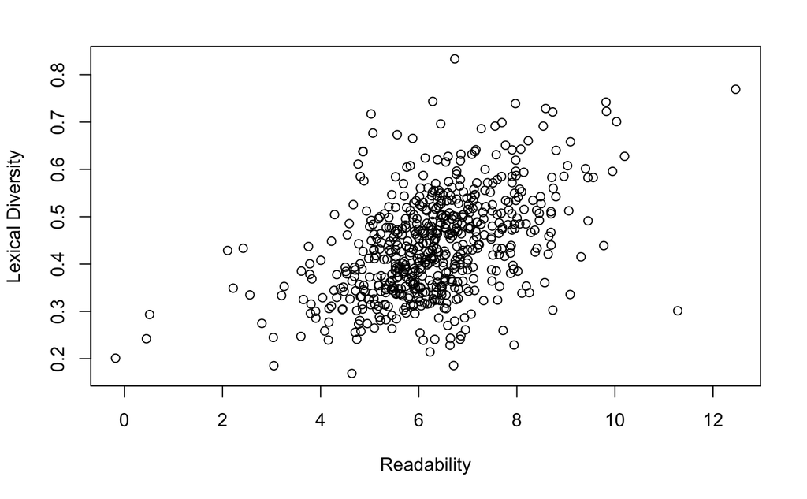

```r
# Rap Plots
plot(rap_coleman, rap_ld_all, xlab = "Readability", ylab = "Lexical Diversity")
```

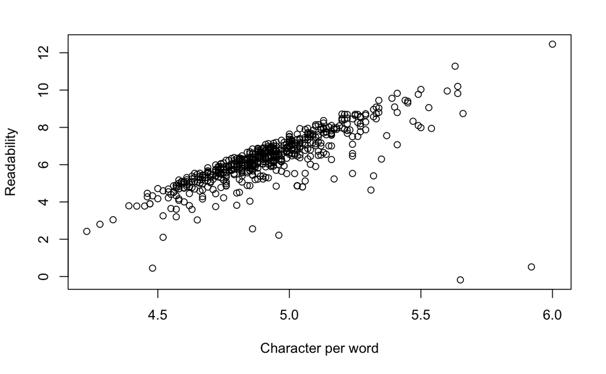

```r
plot(rap_cpw, rap_coleman, xlab = "Character per word", ylab = "Readability")
```

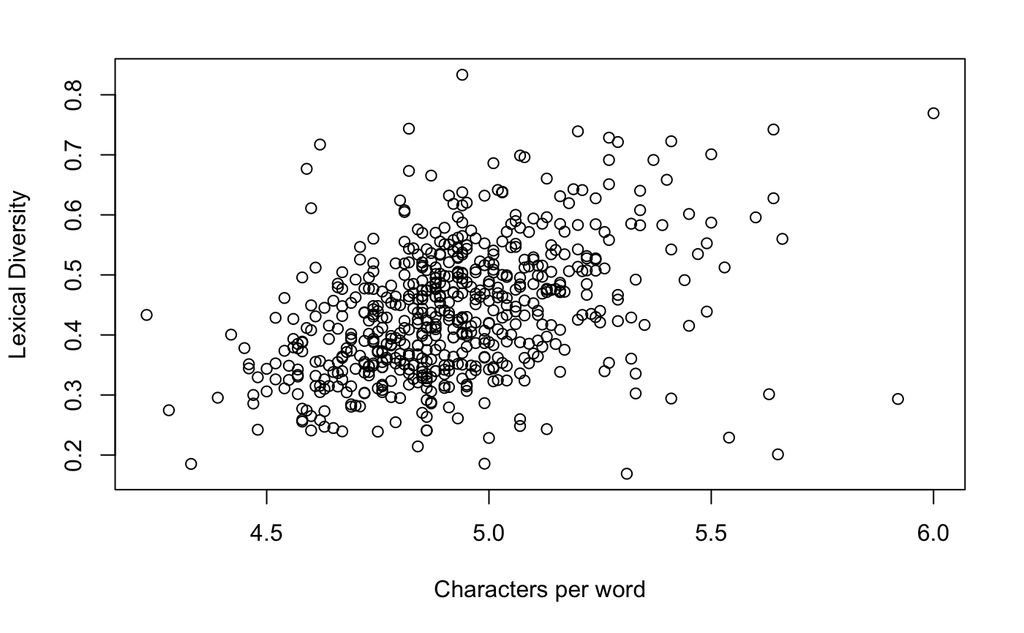

```r
plot(rap_cpw, rap_ld_all, xlab = "Characters per word", ylab = "Lexical Diversity")
```

What does this tell you about the relationship between these three aspects of text?

## Homework

### Part 1: Text pre-processing

Among the various researchers-degrees-of-freedom in natural language processing are decisions about:

- the stemming of words
- the removal of punctuation
- the removal of stopwords
- lower-casing the corpus
- the sparsity trimming

Use a corpus of your choice and build a TFIDF matrix for the original corpus and all possible combinations from the decisions to-be-made above. All of these can be done using base R and quanteda.

*Hint: for the sparsity trimming, have a look at [this function](https://quanteda.io/reference/dfm_trim.html)*.

### Part 2: Practising with the `quanteda` package

The R package {`quanteda`}(https://quanteda.io/index.html) is a powerful toolbox to deal with text data in R. You will likely need this package for the natural language processing part of your final project. Do learn more about this package, read through and replicate for yourself these two tutorials:

- [Examining literature with quanteda in R](https://quanteda.io/articles/pkgdown/replication/digital-humanities.html)
- [Analysing social media (Twitter) data with quanteda](https://quanteda.io/articles/pkgdown/examples/twitter.html)

### Part 3: Preparation for next week

Please ensure that you have installed and can load the following R packages:

- syuzhet
- spacyr